# [MÉDÉE als »rituelle Zeremonie der Reinigung, Läuterung und Beruhigung« ‒ Peter Sellars über seine Neuproduktion](https://blog.staatsoper-berlin.de/medee-als-rituelle-zeremonie-der-reinigung-laeuterung-und-beruhigung-%e2%80%92-peter-sellars-ueber-seine-neuproduktion/)

0 Kommentare – Veröffentlicht am 9. November 2023 in [Hintergrund](https://blog.staatsoper-berlin.de/kategorie/hintergrund/), [Insights by](https://blog.staatsoper-berlin.de/kategorie/hintergrund/insights-by/)

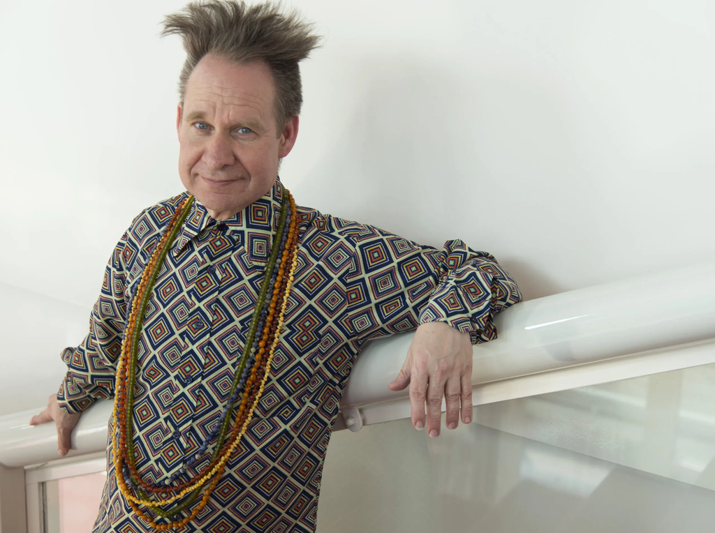

Was sagt uns die griechische Mythologie? Wie relevant sind die antiken Erzählungen für uns Menschen der Neuzeit? Peter Sellars holt den Topos der Medea in die Gegenwart und bringt ihn mit Charpentiers Barockoper »Médée« auf die Bühne – eine Inszenierung, die tief in die persönlichen Schicksale der Figuren und deren menschliche Abgründe einsteigt. In einem Regie-Kommentar gibt er Einblicke in die Hintergründe der Neuproduktion.

Was bedeutet es, seine Kinder zu opfern? Die Kinder, die man liebt? Wir leben heute in einer Zeit und in Ländern, die kein Problem damit haben, die nächste Generation zu opfern. Vielleicht hat uns der Mythos von Medea etwas zu sagen. Und der Mythos könnte darauf hindeuten, dass unsere Kinder und ihre Mütter eine Menge zu sagen haben, was wir nicht hören.

Wir leben in einer Welt der organisierten Rechts-, Wirtschafts- und Einwanderungspolitik, in der der höchste Preis für das menschliche Leben von Frauen und Kindern gezahlt wird, aber fast alle Entscheidungen werden und wurden von Männern getroffen. Das Bild der verrückten Zauberin, der Hexe, der bösen Mutter, der weiblichen Kindermörderin ist reißerisch ausgearbeitet worden, um das überwältigende Übermaß der Gewalt gegen Frauen und Kinder zu verschleiern, welches unsere Zeit und die meisten Epochen vor uns kennzeichnet. Sicherlich sind Frauen und Kinder die Hauptleidtragenden heutiger Kriege in den Innenstädten unserer modernen Metropolen und in so vielen ländlichen Gebieten.

> Moralische Fragen standen im Mittelpunkt von Charpentiers Lebenswerk.

Euripides und Corneille machen deutlich, dass Medea eine Ausländerin (»barbare«) ist, eine Immigrantin, und daher ein geeignetes Objekt der Schuldzuweisung; es ist eine Herausforderung für unsere Gesellschaft, wenn jemand aus dem Chaos kommend harte Wahrheiten in eine »stabile« Gesellschaft trägt, die durch vereinbarte Halbwahrheiten zusammengehalten wird. Jeder Mann, sowohl im Mythos als auch in den Medea-Theaterstücken und -Opern, ist ein Lügner. Medea spricht die Wahrheit, aber nach einer Weile beginnt sie, verrückt zu werden. Kommt Ihnen das bekannt vor?

Marc-Antoine Charpentier war in erster Linie ein Komponist geistlicher Musik, und moralische Fragen standen im Mittelpunkt seines Lebenswerks. »Médée«, ein Auftragswerk der Académie Royale de Musique, komponiert auf ein scharfsinniges Libretto von Thomas Corneille, war Charpentiers einzige offizielle Oper. Das ist nicht verwunderlich, wenn man bedenkt, dass das Stück mit einem Lobgesang auf den Widmungsträger Ludwig XIV. beginnt (der bei mindestens zwei Aufführungen in der königlichen Loge anwesend war), aber im vierten Akt den »König« als geistesgestörten Mörder zeigt, der sich dem gesammelten Gewicht seiner bösen Taten in einer von ihm selbst geschaffenen Hölle stellen muss. Charpentier wurde nicht wieder an das Opernhaus eingeladen.

Trotz des Misserfolgs zu Charpentiers Lebzeiten bietet »Médée« vier Jahrhunderte später einen Einblick in andere Welten und nicht eingeschlagene Wege. Zusammen mit Henry Purcells »Dido and Aeneas«, einer fünfundvierzigminütigen Oper, die etwa zur gleichen Zeit für eine Mädchenschule komponiert wurde, bietet Charpentiers »Médée« eine visionäre und transzendente Meditation über die Möglichkeiten der Oper, geschaffen von einem Außenseiter im ersten Jahrhundert der neuen Kunstform. Die Gattung war noch frisch, in vielerlei Hinsicht unerforscht und doch auf seltsame Weise verfügbar und in der Lage, das Schwere des siebzehnten Jahrhunderts mit Surrealismus und Melancholie, politischer Lähmung, religiöser Unterdrückung und den Gespenstern des andauernden Krieges und der Pest zu vermitteln, und das alles in Verbindung mit einem gleichzeitigen unterirdischen Archipel menschlicher Intimität, Erotik und psychischer Extreme. Sowohl Charpentier als auch Purcell schufen eine geisterhafte und erhabene Musik, deren Hunger und spirituelle Sehnsucht uns noch zu Beginn des einundzwanzigsten Jahrhunderts berührt.

> In Charpentiers Konstrukt der Enttäuschung und Selbstzerstörung befindet sich ein fließender Kosmos der Zärtlichkeit, der Freundlichkeit, der Fürsorge und der Heilung.

Die neue moderne Kunstform der Oper war in der Lage, gleichzeitige und sich gegenseitig durchdringende Realitäten und Widersprüche, innere und äußere Kämpfe sowie öffentliche Ereignisse eingebettet in intime metaphysische Landschaften darzustellen und zu vermitteln. Charpentiers unendlich flexible und sich ständig verändernde musikalische Rhetorik, die Rezitative, Ariosi, große und kleine Chorstrukturen und kontrastierende Tanzepisoden durchläuft, bewegt sich an den Rändern des menschlichen Bewusstseins, innerhalb von Räumen, in denen eine Emotion in eine andere übergeht, ethische Klarheit sich auflöst, Zweckmäßigkeit zu Gift wird und wir uns von der Wahrheit unserer Täuschungen überzeugen können. Jede Figur in »Médée« ringt mit ihrem Gewissen. Ist das, was ich tue, moralisch, ethisch und richtig? Immer wieder ist die Antwort klar: Nein, das ist es nicht. Und dann tut die Figur mit offenen Augen das Falsche. Überwältigend. Das ist menschlich, und das ist Oper.

In Charpentiers Konstrukt der Enttäuschung und Selbstzerstörung befindet sich ein fließender Kosmos der Zärtlichkeit, der Freundlichkeit, der Fürsorge und der Heilung. Diese Oper ist eine rituelle Zeremonie der Reinigung, Läuterung und Beruhigung. Ihre Qualen sind Balsam für die Seele. In vorausschauender Harmonie mit seinem deutschen Nachfolger Johann Sebastian Bach sind Charpentiers Passacaglien und Sarabanden Tanzmusik und Trance-Musik, die die Knoten des Herzens und des Verstandes entwirren und lösen, den tödlichen Zorn besänftigen und beseitigen, Mitgefühl erzeugen und das gestörte und gestresste menschliche und göttliche Ökosystem wieder heilen. Und wie alle Tragödien ist »Médée« eine Aufforderung an die Menschheit, innezuhalten, hinzuschauen, zu fühlen und den Kurs bewusst zu ändern, bevor es zu spät ist.

Text von Peter Sellars

Aus dem Englischen übersetzt von Hannah Reynolds Bezuijen

###### [MÉDÉE](https://www.staatsoper-berlin.de/de/veranstaltungen/medee.12155/#event-68663)

Schon unter den Zeitgenossen gab es Stimmen höchsten Lobes: Unzweifelhaft sei Marc-Antoine Charpentiers »Médée« dasjenige Werk nach dem Tode Lullys – dem Begründer der französischen Oper zur Zeit des Sonnenkönigs –, in dem ein besonderes Können zutage tritt. Viel könne man angesichts dieser »Médée« über die Kunst der Komposition lernen, über das organische Zusammenwirken von Text und Musik, über die Vergegenwärtigung eines vielschichtigen tragischen Geschehens, dessen Größe und Kraft unmittelbar zu berühren weiß. Charpentiers Oper ist in ihrer Verbindung von französischer Klassizität mit italienischer Melodienschönheit einzigartig, singulär auch in ihrem Ausdrucks- und Klangfarbenreichtum. Eine jede Figur gewinnt scharfes Profil, so wie auch das Drama selbst, das von Peter Sellars in Szene gesetzt wird, mit Brückenschlägen aus mythischer Zeit in die Gegenwart hinein, einmal mehr unterstreichend, wie aktuell und wirkungsmächtig die altgriechische Sagenwelt doch für uns ist.  
[Mehr erfahren](https://www.staatsoper-berlin.de/de/veranstaltungen/medee.12155/#event-68663)

###### [Peter Sellars](https://www.staatsoper-berlin.de/de/kuenstler/peter-sellars.3292/)

[Zur Biografie](https://www.staatsoper-berlin.de/de/kuenstler/peter-sellars.3292/)